# Explore Difference in Precipitation

Benedito Chou

2019-03-25

## Setup Library

Install these packages if neccessary.

```r
library(readr)
library(tidyr)
library(knitr)
library(DT)
library(dplyr)
library(stringr)
library(scales)
library(broom)
library(ggplot2)
library(ggbeeswarm)
```

## Data Preparation

### Load Data

Load the data imported, processed and saved from “data wrangle change score centroid and map data.R”.

```r
load("processed_data v2.RData")
```

### Prepare Data

Keep distinct records within each time point only because keeping all pairwise records will inflate the number of observations in time 1 and 2.

```r
data_long <- distinct(merged_data_record_all_long, tribe, time, FIPS, .keep_all = TRUE)
```

Create data.frame to include only tribes with time 1 and 2 data.

```r
data_t1and2_long <- filter(data_long, tribe %in% tribes_time1and2_lst$tribe)
```

**Check Data**

First, confirm the data is correct, each tribe should have 2 summarized records in total, one for time 1 and one for time 2, so the resulted data.frame should has 0 row.

```r
t1and2_lst <- group_by(data_t1and2_long, tribe, time) %>%
  count() %>%
  ungroup() %>%
  group_by(tribe) %>%
  count() %>%
  filter(n < 2)

nrow(t1and2_lst)
```

```
## [1] 0
```

## Exploratory Analyses

### Plot Precipitation by Time

### All Tribes, including those with time 1 or time 2 data only

- The distribution of precipitation in time 1 and time 2 is slightly skewed to the right.
- The distirbution of precipitation is in general lower in time 2 compared to time 1.

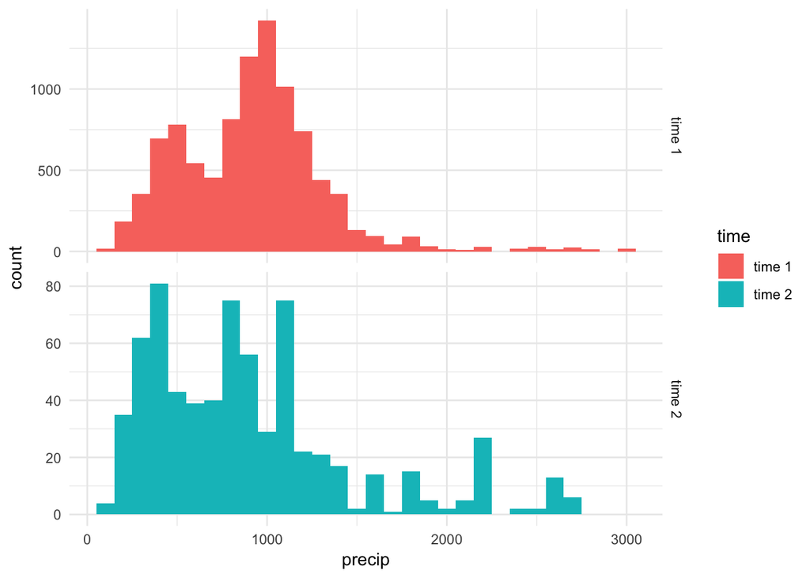

```r
ggplot(data_long, aes(precip, fill = time)) +
  facet_grid(rows = vars(time), scales = "free") +
  geom_histogram(position = "dodge", binwidth = 100) +
  theme_minimal()
```

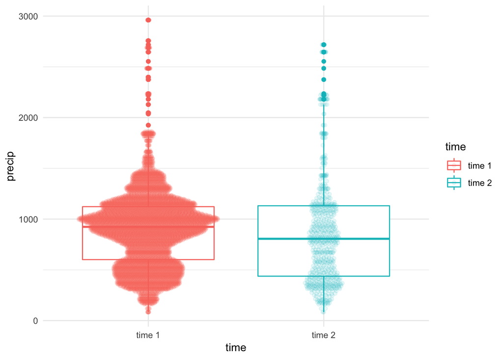

```r
ggplot(data_long, aes(time, precip, colour = time)) +
  geom_boxplot() +
  geom_quasirandom(alpha = 1/10, varwidth = TRUE) +
  theme_minimal()
```

### Tribes with both time 1 or time 2 data

- The distribution of precipitation in time 1 and time 2 is slightly skewed to the right.
- The distirbution of precipitation is in general lower in time 2 compared to time 1.

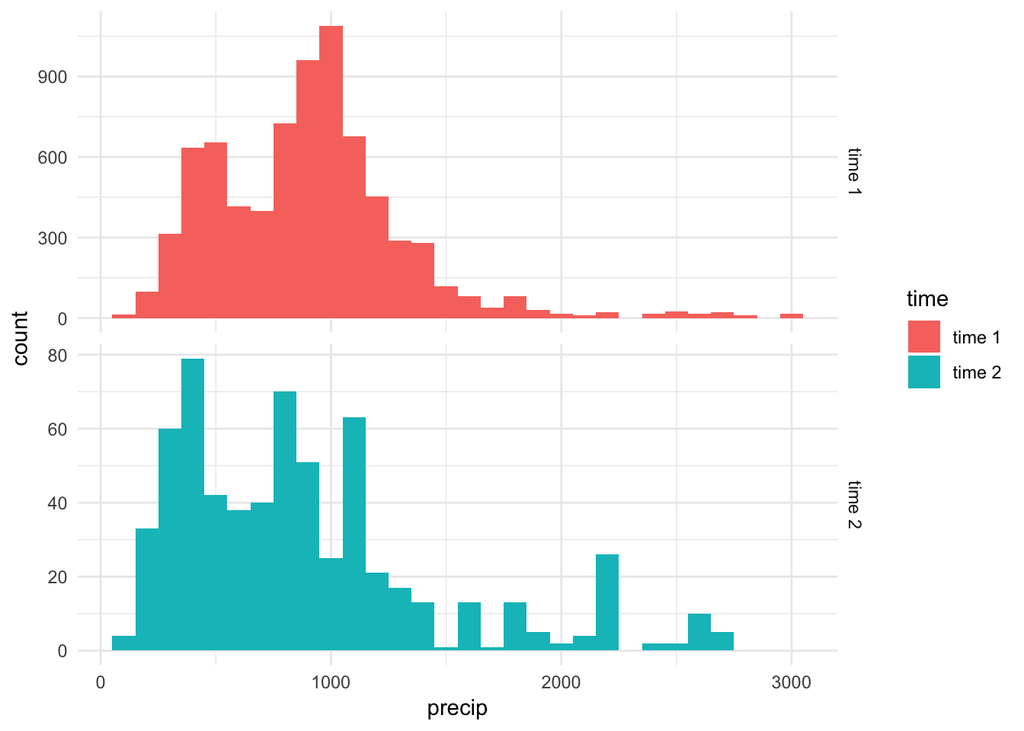

```r
ggplot(data_t1and2_long, aes(precip, fill = time)) +
  facet_grid(rows = vars(time), scales = "free") +
  geom_histogram(position = "dodge", binwidth = 100) +
  theme_minimal()
```

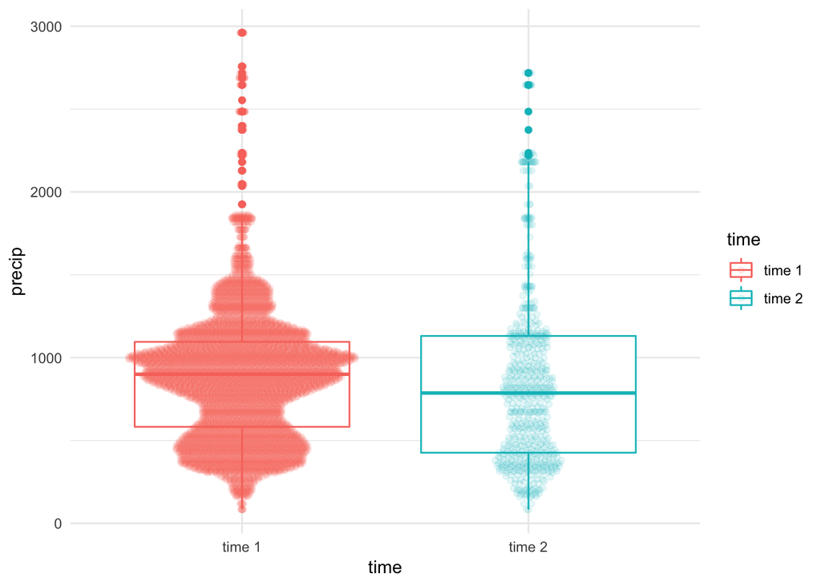

```r
ggplot(data_t1and2_long, aes(time, precip, colour = time)) +
  geom_boxplot() +
  geom_quasirandom(alpha = 1/10, varwidth = TRUE) +
  theme_minimal()
```

## Test for Significant Difference

### (1) Test for significant difference at the aggregate level

- Welch’s t-test (t.test, paired = FALSE) is a parameteric test for two-sample mean comparisions that does not assume equal variance.
- Use Welch’s t-test because the outcome precipitation is a continous measures.
- Welch’s t-test for dependent sample is not used because these are not true paired data, since we don’t know which time 1 locations migrate to which time 2 locations and simply assume all possible migration routes happened.

### Use all records

```r
ttest_model <- t.test(precip ~ time, data = data_long, paired = FALSE)

ttest_model
```

```
##
##  Welch Two Sample t-test
##
## data:  precip by time
## t = 0.2028, df = 739.14, p-value = 0.8393
## alternative hypothesis: true difference in means is not equal to 0
## 95 percent confidence interval:
##  -39.98078  49.19255
## sample estimates:
## mean in group time 1 mean in group time 2
##             912.7505             908.1447
```

```r
ttest_model <- tidy(ttest_model)

mean_t1 <- round(mean(filter(data_long, time == "time 1")$precip, na.rm = T), 2)
mean_t2 <- round(mean(filter(data_long, time == "time 2")$precip, na.rm = T), 2)
sd_t1 <- round(sd(filter(data_long, time == "time 1")$precip, na.rm = T), 2)
sd_t2 <- round(sd(filter(data_long, time == "time 2")$precip, na.rm = T), 2)

pvalue <- round(ttest_model$p.value, 3)
tvalue <- round(ttest_model$statistic, 3)
degreef <- round(ttest_model$parameter, 3)
```

**Interpretation**

- At the aggregate level, the difference in precipitation between time 1 (M = 912.75, SD = 400.4) and time 2 (M = 908.14, SD = 588.1) was not statistically signficant (t(739.137)= 0.203, p = 0.839).

### Use only records where tribes have time 1 and 2 data

```r
ttest_model <- t.test(precip ~ time, data = data_t1and2_long, paired = FALSE)

ttest_model
```

```
##
##  Welch Two Sample t-test
##
## data:  precip by time
## t = 0.59691, df = 694.66, p-value = 0.5508
## alternative hypothesis: true difference in means is not equal to 0
## 95 percent confidence interval:
##  -32.09259  60.13037
## sample estimates:
## mean in group time 1 mean in group time 2
##             899.9031             885.8842
```

```r
ttest_model <- tidy(ttest_model)

mean_t1 <- round(mean(filter(data_t1and2_long, time == "time 1")$precip, na.rm = T), 2)
mean_t2 <- round(mean(filter(data_t1and2_long, time == "time 2")$precip, na.rm = T), 2)
sd_t1 <- round(sd(filter(data_t1and2_long, time == "time 1")$precip, na.rm = T), 2)
sd_t2 <- round(sd(filter(data_t1and2_long, time == "time 2")$precip, na.rm = T), 2)

pvalue <- round(ttest_model$p.value, 3)
tvalue <- round(ttest_model$statistic, 3)
degreef <- round(ttest_model$parameter, 3)
```

**Interpretation**

- At the aggregate level for tribes with migration, the difference in precipitation between time 1 (M = 899.9, SD = 411.62) and time 2 (M = 885.88, SD = 581.85) was also not statistically signficant (t(694.659)= 0.597, p = 0.551).

### (NEW) Test for significant difference at the aggregate level

### Alternative Test - Using Repeated Measure ANOVA

Restructure data for repeated measure ANOVA and convert tribe and time as factor for modeling

```r
data_wide <- filter(merged_data_record_all, time == "Time 1 and 2")

precip_data_wide <- select(data_wide, ID, tribe, FIPS_t1, FIPS_t2, time, precip_t1, precip_t2, precip_change_score) %>%
  filter(!is.na(precip_t1), !is.na(precip_t2))

precip_data_long <- gather(precip_data_wide, "time", "precip", -ID, -tribe, -time, -precip_change_score, -FIPS_t1, -FIPS_t2) %>% ungroup() %>%
  mutate(tribe = factor(tribe),
         time = factor(time))
```

### Repeated Measure ANOVA

- If we assume pairwise migrations between counties occured for each tribe, Repeated Measure ANOVA is a parameteric test appropriate for making paired sample mean comparisions over time.
- Use Repeated Measure ANOVA because the outcome precipitation is a continous measures and is predicted by a single within subject factor (time).
- Repeated Measure ANOVA can only be run with tribes with both time 1 and time 2 data.

### Use only records where tribes have time 1 and 2 data

```r
aov_model <- aov(precip ~ time + Error(tribe / time), data = precip_data_long)

summary(aov_model)
```

```
##
## Error: tribe
##            Df     Sum Sq  Mean Sq F value Pr(>F)
## Residuals 183 8830587959 48254579
##
## Error: tribe:time
##            Df    Sum Sq   Mean Sq F value       Pr(>F)
## time        1 114310567 114310567   35.89 0.0000000108 ***
## Residuals 183 582798938   3184694
## ---
## Signif. codes:  0 '***' 0.001 '**' 0.01 '*' 0.05 '.' 0.1 ' ' 1
##
## Error: Within
##               Df     Sum Sq Mean Sq F value Pr(>F)
## Residuals 117584 3972555800   33785
```

```r
aov_model <- tidy(aov_model)

pvalue <- round(aov_model$p.value[2], 3)
Fvalue <- round(aov_model$statistic[2], 2)
degreef1 <- aov_model$df[2]
degreef2 <- aov_model$df[3]
```

**Interpretation**

- At the aggregate level for tribes with migration, the difference in precipitation between time 1 (M = 899.9 SD = 411.62) and time 2 (M = 885.88, SD = 581.85) was statistically signficant (F(1, 183)= 35.89, p < .001).

### (2) Test for significant difference at tribe level

```r
no_test <- group_by(data_t1and2_long, tribe) %>%
do(tryCatch( {tidy(t.test(precip ~ time, data = ., paired = FALSE))},
  error = function(e) {tidy(t.test(precip ~ time, data = data_t1and2_long)) %>% mutate(estimate = NA)}
    ))

no_test[!!rowSums(is.na(no_test)),-1] <- NA

no_test <- no_test %>%
  filter(!is.na(p.value)) %>%
  nrow()
```

This can only be tested with the 184 tribes where migrations occured. Furthermore, only tribes where precipitation have changed between time points and with more than one data point at each time point can their differences be tested for statistical significance. This reduce the number of tribes from 184 to 110.

### Run Welch’s t-test in Batch

- Run Welch’s t-test in batch using group_by and do at the tribe level.
- Include a try call to catch error.
- Use tidy from broom package to format the results into a data.frame.
- Replace NA estimate with all NA for that comparison.

```r
model <- group_by(data_t1and2_long, tribe) %>%
do(tryCatch( {tidy(t.test(precip ~ time, data = ., paired = FALSE))},
  error = function(e) {tidy(t.test(precip ~ time, data = data_t1and2_long)) %>% mutate(estimate = NA)}
    ))

model[!!rowSums(is.na(model)),-1] <- NA
```

Calculate number of test based only on tribes where there is non-zero difference and sufficient data point in precipitation between time 1 and 2.

```r
no_test <- nrow(filter(model, !is.na(p.value)))
```

```r
model <- model %>%
  mutate(sig = ifelse(p.value < .05 / no_test, "yes", "no"))
```

- Add average precipitation, distance, and no of unique FIPS to help with interpretation
- Rename some variables for prettier column headers

```r
results_df <- inner_join(model, merged_data_tribe, by = "tribe") %>%
  mutate(`Avg Diff Precipitation` = avg_precip_t2 - avg_precip_t1) %>%
  select(tribe, sig, p.value, `Avg Diff Precipitation`, avg_precip_t1, avg_precip_t2, n_unique_FIPS_t1, n_unique_FIPS_t2, mid_dist) %>%
  arrange(p.value) %>%
  rename(
    `Avg Precipitation T1` = avg_precip_t1,
    `Avg Precipitation T2` = avg_precip_t2,
    `Unique FIPS T1` = n_unique_FIPS_t1,
    `Unique FIPS T2` = n_unique_FIPS_t2,
    `Mid Distance` = mid_dist)
```

### Results Table

#### Ordered by p value in ascending order

```r
datatable(results_df,
          filter = "top",
          options = list(pageLength = 20)) %>%
   formatRound(columns = c('p.value'), digits = 3) %>%
   formatRound(columns = c('Avg Diff Precipitation', 'Avg Precipitation T1', 'Avg Precipitation T2', 'Mid Distance'), digits = 2)
```

|  | tribe | sig | p.value | Avg Diff Precipitation | Avg Precipitation T1 | Avg Precipitation T2 | Unique FIPS T1 | Unique FIPS T2 | Mid Distance |
| --- | --- | --- | --- | --- | --- | --- | --- | --- | --- |
| 1 | Chippewa | yes | 7.65971764872784e-09 | -159.144717716609 | 863.340896419048 | 704.196178702439 | 383 | 41 | 535.353093075632 |
| 2 | Chickasaw | yes | 3.25206724173733e-08 | -311.282148371228 | 1258.30399979123 | 947.02185142 | 114 | 5 | 579.67663336682 |
| 3 | Sioux | yes | 9.45237357920287e-08 | -148.790762288889 | 649.341668672222 | 500.550906383333 | 271 | 31 |  |
| 4 | Caddo | yes | 1.66999039781512e-07 | -499.9200087 | 1315.578524 | 815.6585153 | 4 | 6 | 528.988162482006 |
| 5 | Comanche | yes | 6.65769075641692e-07 | 227.804229100275 | 608.422724174725 | 836.226953275 | 182 | 8 | 227.231109520749 |
| 6 | Kiowa | yes | 6.65769075641692e-07 | 227.804229100275 | 608.422724174725 | 836.226953275 | 182 | 8 | 227.231109520749 |
| 7 | Sisseton | yes | 3.32914354094707e-06 | -66.22219103977 | 661.897912082627 | 595.675721042857 | 238 | 7 |  |
| 8 | Cayuga | yes | 0.000298498248416366 | 142.166082107619 | 1002.07368222571 | 1144.23976433333 | 70 | 4 | 511.431485906177 |
| 9 | Lenape | no | 0.000886058876966944 | -212.794621117675 | 1059.84231551767 | 847.0476944 | 215 | 7 | 1329.2066718248 |
| 10 | Arapaho | no | 0.00289933338392336 | 205.291306025217 | 473.845512974783 | 679.136819 | 115 | 11 | 436.768817430388 |

[output cut: 174 more lines]

```r
b_sig_tribe_lst <- filter(results_df, sig == "yes") %>%
  select(tribe)
sig_tribe_lst <- filter(results_df, p.value < .05) %>%
  select(tribe)
```

**Interpretation**

- The mean precipitation comparisons for 8 tribes (Chippewa, Chickasaw, Sioux, Caddo, Comanche, Kiowa, Sisseton, Cayuga) achieve statistical significance when the Bonferroni correction is used.
- The tests have low statistical power to detect differences given the number of observations at time 2 is much smaller than time 1.
- If Bonferroni correction is not used, precipitation was significantly differ between time 1 and 2 for 23 tribes :(Chippewa, Chickasaw, Sioux, Caddo, Comanche, Kiowa, Sisseton, Cayuga, Lenape, Arapaho, Cheyenne, Creek, Chinook, Shoshone, Cowlitz, Arikara, Cherokee, Potawatomi, Iowa, Pawnee, Hidatsa, Mandan, Gros Ventre).
- Results with NA p values are from tribes where there isn’t sufficient data points in both time point to perform the planned statistical tests (Welch’s t-test).

**Overall Interpretation**

- Overall, no statistically significant difference was found at the aggregate level. At the tribe level, when correction for multiple comparisons was made, precipitations for 8 tribes were found to be statistically differ between time 1 and time 2.
- The lack of significant differences at the tribe level could be attributed to the low statistical power arises from the small number of observations at time 2. In some cases, there is only 1 data point in time 2 or time 1, which preclude the use of Welch’s t-test to test for their mean differences.

### (NEW) Run Repeated Measure ANOVA in Batch

- Run repeated measure ANOVA in batch using group_by and do at the tribe level.
- Include a try call to catch error.
- Use tidy from broom package to format the results into a data.frame.
- Replace NA estimate with all NA for that comparison.
- Filter out tribes where test cannot be run due to insufficient sample size.

```r
model <- group_by(precip_data_long, tribe) %>%
do(tryCatch( {tidy(aov(precip ~ time + Error(ID / time), data = .))},
  error = function(e) {tidy((aov(precip ~ time + Error(ID / time), data = .))) %>% mutate(estimate = NA)}
    ))

model[!!rowSums(is.na(model)),-1] <- NA

model <- filter(model, stratum == "Within", term == "time")
```

Calculate number of test based only on tribes where there is non-zero difference in percipitation between time 1 and 2.

```r
no_test <- nrow(filter(model, !is.na(p.value)))
```

```r
model <- model %>%
  mutate(sig = ifelse(p.value < .05 / no_test, "yes", "no"))
```

- Add average precipitation, distance, and no of unique FIPS to help with interpretation
- Rename some variables for prettier column headers

```r
results_df <- inner_join(model, merged_data_tribe, by = "tribe") %>%
  mutate(`Avg Diff Precipitation` = avg_precip_t2 - avg_precip_t1) %>%
  select(tribe, sig, p.value, `Avg Diff Precipitation`, avg_precip_t1, avg_precip_t2, n_unique_FIPS_t1, n_unique_FIPS_t2, mid_dist) %>%
  arrange(p.value) %>%
  rename(
    `Avg Precipitation T1` = avg_precip_t1,
    `Avg Precipitation T2` = avg_precip_t2,
    `Unique FIPS T1` = n_unique_FIPS_t1,
    `Unique FIPS T2` = n_unique_FIPS_t2,
    `Mid Distance` = mid_dist)
```

### Results Table

#### Ordered by p value in ascending order

```r
datatable(results_df,
          filter = "top",
          options = list(pageLength = 20)) %>%
   formatRound(columns = c('p.value'), digits = 3) %>%
   formatRound(columns = c('Avg Diff Precipitation', 'Avg Precipitation T1', 'Avg Precipitation T2', 'Mid Distance'), digits = 2)
```

|  | tribe | sig | p.value | Avg Diff Precipitation | Avg Precipitation T1 | Avg Precipitation T2 | Unique FIPS T1 | Unique FIPS T2 | Mid Distance |
| --- | --- | --- | --- | --- | --- | --- | --- | --- | --- |
| 1 | Chippewa | yes | 0 | -159.144717716609 | 863.340896419048 | 704.196178702439 | 383 | 41 | 535.353093075632 |
| 2 | Lenape | yes | 0 | -212.794621117675 | 1059.84231551767 | 847.0476944 | 215 | 7 | 1329.2066718248 |
| 3 | Sioux | yes | 0 | -148.790762288889 | 649.341668672222 | 500.550906383333 | 271 | 31 |  |
| 4 | Sisseton | yes | 5.33547080032729e-279 | -66.22219103977 | 661.897912082627 | 595.675721042857 | 238 | 7 |  |
| 5 | Choctaw | yes | 4.81501281439518e-149 | -20.3369063301 | 1295.1410590176 | 1274.8041526875 | 125 | 16 | 146.342424553144 |
| 6 | Potawatomi | yes | 7.52764474799638e-144 | -67.2219472725275 | 972.554915605861 | 905.332968333333 | 275 | 13 | 288.610536701408 |
| 7 | Apache | yes | 2.1313340734637e-130 | 123.822035169231 | 509.4226683 | 633.244703469231 | 188 | 13 | 147.603935135308 |
| 8 | Comanche | yes | 4.57475507042282e-112 | 227.804229100275 | 608.422724174725 | 836.226953275 | 182 | 8 | 227.231109520749 |
| 9 | Kiowa | yes | 4.57475507042282e-112 | 227.804229100275 | 608.422724174725 | 836.226953275 | 182 | 8 | 227.231109520749 |
| 10 | Cheyenne | yes | 3.03470275378977e-92 | 198.022941488636 | 483.887461575 | 681.910403063636 | 96 | 11 | 345.826468392626 |

[output cut: 148 more lines]

```r
b_sig_tribe_lst <- filter(results_df, sig == "yes") %>%
  select(tribe)
sig_tribe_lst <- filter(results_df, p.value < .05) %>%
  select(tribe)
```

**Interpretation**

- The mean precipitation comparisons for 47 tribes (Chippewa, Lenape, Sioux, Sisseton, Choctaw, Potawatomi, Apache, Comanche, Kiowa, Cheyenne, Pawnee, Iowa, Arapaho, Chickasaw, Absentee-Shawnee, Kickapoo, Chiricahua Apache, Hidatsa, Mandan, Arikara, Cayuga, Cherokee, Missouria, Caddo, Omaha, Creek, Seminole, Otoe, Seneca, Ute, Quapaw, Tuscarora, Appalachicola, Santee Sioux, Mohican, Washoe, Miami, Menominee, Wyandotte, Catawba, Yankton Sioux, Kaw, Tuolumne Me-Wuk, Chukchansi, Kaskaskia, Paiute, Osage) achieve statistical significance when the Bonferroni correction is used.
- The tests has low statistical power to detect differences given the number of observations at time 2 is much smaller than time 1.
- If Bonferroni correction is not used, precipitation was significantly differ between time 1 and 2 for 71 tribes :(Chippewa, Lenape, Sioux, Sisseton, Choctaw, Potawatomi, Apache, Comanche, Kiowa, Cheyenne, Pawnee, Iowa, Arapaho, Chickasaw, Absentee-Shawnee, Kickapoo, Chiricahua Apache, Hidatsa, Mandan, Arikara, Cayuga, Cherokee, Missouria, Caddo, Omaha, Creek, Seminole, Otoe, Seneca, Ute, Quapaw, Tuscarora, Appalachicola, Santee Sioux, Mohican, Washoe, Miami, Menominee, Wyandotte, Catawba, Yankton Sioux, Kaw, Tuolumne Me-Wuk, Chukchansi, Kaskaskia, Paiute, Osage, Mdewakanton Sioux, Peoria, Modoc, Yakama, Goshute, Pomo, Oneida, Ottawa, Me-Wuk, Gros Ventre, Wintun, Skagit, Clatsop, Shoshone, Crow, Duwamish, Klamath, Rogue River, Tolowa, Yavapai, Ponca, Shawnee, Cowlitz, Tillamook).
- Of the 184 tribes with migrations, 26 has insufficient data points in both time points to perform the planned statistical tests (repeated measure ANOVA).

**Overall Interpretation**

- Overall, a statistically significant difference was found at the aggregate level. At the tribe level, when correction for multiple comparisons was made, precipitation for 47 tribes were found to be statistically differ between time 1 and time 2. Without correction, precipitation was found to be statistically differ for 71 tribes.
- The lack of significant differences at the tribe level could be attributed to the low statistical power arises from the small number of observations at time 2. In some cases, there is only 1 data point in time 2 or time 1, which preclude the use of repeated measure ANOVA to test for their mean differences.
- Between the two set of tests (independent t-test and repeated measure ANOVA), the independent tests is more conservative when come to achieving statistical significance and the repeated measures ANOVA is more powerful in detecting observed differences in paired data. The repeated measure tests also have more significant findings because we have many more observations by using all-pairs and partialling out the intra-correlations.